# Chapter 2 - Making Predictions

Edneide Ramalho

17 Janeiro, 2022

# 1 Imports

```r
library(fst) # to read fst format
library(tidyverse)

# data
taiwan_real_estate <- read_fst(
  "taiwan_real_estate.fst",
  columns = NULL,
  from = 1,
  to = NULL,
  as.data.table = FALSE,
  old_format = FALSE
)

glimpse(taiwan_real_estate)
```

```
## Rows: 414
## Columns: 4
## $ dist_to_mrt_m   <dbl> 84.87882, 306.59470, 561.98450, 561.98450, 390.56840, …
## $ n_convenience   <dbl> 10, 9, 5, 5, 5, 3, 7, 6, 1, 3, 1, 9, 5, 4, 4, 2, 6, 1,…
## $ house_age_years <ord> 30 to 45, 15 to 30, 0 to 15, 0 to 15, 0 to 15, 0 to 15…
## $ price_twd_msq   <dbl> 11.467474, 12.768533, 14.311649, 16.580938, 13.040847,…
```

*Extrapolating* means making predictions outside the range of observed data.

# 2 **Predicting house prices**

Perhaps the most useful feature of statistical models like linear regression is that you can make predictions. That is, you specify values for each of the explanatory variables, feed them to the model, and you get a prediction for the corresponding response variable. The code flow is as follows.

```
explanatory_data <- tibble(
  explanatory_var = some_values
)
explanatory_data %>%
  mutate(
    response_var = predict(model, explanatory_data)
  )
```

Here, you’ll make predictions for the house prices in the Taiwan real estate dataset.

`taiwan_real_estate` is available. The linear regression model of house price versus number of convenience stores is available as `mdl_price_vs_conv` (*print it and read the call to see how it was made*); and `dplyr` is loaded.

- Create a tibble of explanatory data, where the number of convenience stores, `n_convenience`, takes the integer values from zero to ten.

```r
mdl_price_vs_conv <- lm(formula = price_twd_msq ~ n_convenience, data = taiwan_real_estate)
```

```r
# Create a tibble with n_convenience column from zero to ten
explanatory_data <- tibble(n_convenience = 0:10)
```

- Use the model `mdl_price_vs_conv` to make predictions from `explanatory_data`.

```r
# Use mdl_price_vs_conv to predict with explanatory_data
predict(mdl_price_vs_conv, explanatory_data)
```

```
##         1         2         3         4         5         6         7         8
##  8.224237  9.022317  9.820397 10.618477 11.416556 12.214636 13.012716 13.810795
##         9        10        11
## 14.608875 15.406955 16.205035
```

Create a tibble of predictions named `prediction_data`.

- Start with `explanatory_data`.
- Add an extra column, `price_twd_msq`, containing the predictions.

```r
prediction_data <- explanatory_data %>%
  mutate(
    price_twd_msq = predict(
      mdl_price_vs_conv, explanatory_data
      )
    )
```

## 2.1 **Visualizing predictions**

The prediction data you calculated contains a column of explanatory variable values and a column of response variable values. That means you can plot it on the same scatter plot of response versus explanatory data values.

`prediction_data` is available and `ggplot2` is loaded. The code for the scatter plot with linear trend line you drew in Chapter 1 is shown.

- Extend the plotting code to include the point predictions in `prediction_data`. Color the points yellow.

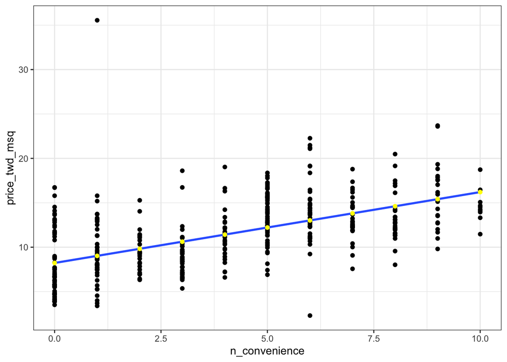

```r
# Add to the plot
ggplot(taiwan_real_estate, aes(n_convenience, price_twd_msq)) +
  geom_point() +
  geom_smooth(method = "lm", se = FALSE) +
  # Add a point layer of prediction data, colored yellow
  geom_point(data = prediction_data, aes(n_convenience, price_twd_msq), color = "yellow") +
  theme_bw()
```

Naturally, the predicted points lie on the trend line.

# 3 **The limits of prediction**

In the last exercise you made predictions on some sensible, could-happen-in-real-life, situations. That is, the cases when the number of nearby convenience stores were between zero and ten. To test the limits of the model’s ability to predict, try some impossible situations.

Use the console to try predicting house prices from `mdl_price_vs_conv` when there are `-1` convenience stores. Do the same for `2.5` convenience stores. What happens in each case?

`mdl_price_vs_conv` is available and `dplyr` is loaded.

Create some impossible explanatory data. Define a tibble with one column, `n_convenience`, set to minus one, assigning to `minus_one`. Create another with `n_convenience` set to two point five, assigning to `two_pt_five`.

```r
# Define a tibble where n_convenience is -1
minus_one <- tibble(n_convenience = -1)

# Define a tibble where n_convenience is 2.5
two_pt_five <- tibble(n_convenience = 2.5)
```

- Try making predictions on your two impossible cases. What happens?

```r
predict(mdl_price_vs_conv, minus_one)
```

```
##        1
## 7.426158
```

```r
predict(mdl_price_vs_conv, two_pt_five)
```

```
##        1
## 10.21944
```

Linear models don’t know what is impossible in real life. That means that they can give you predictions that don’t make any sense when applied to your data. You need to understand what your data means in order to determine whether a prediction is nonsense or not.

# 4 Working with model objects

- **coefficients()**

`coefficients(model_name)`

- **fitted()**

`fitted(modelo_name)`

- **residuals()**

`residuals(modelo_name)`

- **summary()**

`summary(modelo_name)`

- **tidy()**

```r
library(broom)

tidy(model_name)
```

- **augment()**

```r
augment(model_name)
```

- **glance()**

```r
glance(model_name)
```

## 4.1 Extracting model elements

The variable returned by `lm()` that contains the model object has many elements. In order to perform further analysis on the model results, you need to extract the useful bits of it. The model coefficients, the fitted values, and the residuals are perhaps the most important bits of the linear model object.

`mdl_price_vs_conv` is available.

- Print the coefficients of `mdl_price_vs_conv`.

```r
coefficients(mdl_price_vs_conv)
```

```
##   (Intercept) n_convenience
##     8.2242375     0.7980797
```

- Print the fitted values of `mdl_price_vs_conv`.

```r
fitted(mdl_price_vs_conv)
```

```
##         1         2         3         4         5         6         7         8
## 16.205035 15.406955 12.214636 12.214636 12.214636 10.618477 13.810795 13.012716
##         9        10        11        12        13        14        15        16
##  9.022317 10.618477  9.022317 15.406955 12.214636 11.416556 11.416556  9.820397
##        17        18        19        20        21        22        23        24
## 13.012716  9.022317 14.608875 13.810795 10.618477 13.810795  9.022317 13.810795
##        25        26        27        28        29        30        31        32
## 11.416556  9.820397 12.214636 12.214636 11.416556 12.214636  8.224237 13.810795
##        33        34        35        36        37        38        39        40
##  9.022317 13.012716 13.810795  8.224237  9.820397  9.022317 13.012716 12.214636
##        41        42        43        44        45        46        47        48
##  8.224237  8.224237 12.214636 13.012716 11.416556 14.608875 15.406955 10.618477
##        49        50        51        52        53        54        55        56
##  8.224237  9.022317 11.416556  9.022317 10.618477 12.214636 12.214636  8.224237
##        57        58        59        60        61        62        63        64
## 14.608875 13.810795  9.022317 12.214636  9.820397 13.012716 10.618477 11.416556
##        65        66        67        68        69        70        71        72
##  8.224237 14.608875 13.012716 12.214636 13.012716 12.214636 15.406955 10.618477
##        73        74        75        76        77        78        79        80
## 14.608875  8.224237 16.205035  9.022317 10.618477 10.618477  9.820397  9.022317
##        81        82        83        84        85        86        87        88
## 11.416556 13.012716 13.810795 10.618477 13.810795 15.406955  9.022317  8.224237
##        89        90        91        92        93        94        95        96
##  8.224237  8.224237  9.022317  8.224237 11.416556  8.224237 12.214636 12.214636
##        97        98        99       100       101       102       103       104
## 15.406955 10.618477 12.214636 15.406955 11.416556  9.022317 13.012716 13.012716
##       105       106       107       108       109       110       111       112
## 13.012716 13.012716 14.608875  9.022317  9.820397 10.618477 12.214636 13.810795
##       113       114       115       116       117       118       119       120
## 10.618477 13.012716 14.608875  9.820397  9.022317  8.224237 10.618477 12.214636
##       121       122       123       124       125       126       127       128
## 12.214636 12.214636 11.416556  8.224237 13.810795 13.012716 11.416556 12.214636
##       129       130       131       132       133       134       135       136
## 13.012716 13.810795 14.608875 10.618477 12.214636 14.608875 13.012716  8.224237
##       137       138       139       140       141       142       143       144
## 12.214636 13.012716  8.224237 12.214636 12.214636 10.618477 12.214636 12.214636
##       145       146       147       148       149       150       151       152
##  9.022317 12.214636  8.224237 14.608875  8.224237 14.608875 13.810795 15.406955
##       153       154       155       156       157       158       159       160
##  9.022317 13.012716  8.224237  8.224237  8.224237 11.416556 12.214636 11.416556
```

[output cut: 49 more lines]

```
## 10.618477 10.618477  9.022317 12.214636  9.022317 15.406955 13.012716  8.224237
##       361       362       363       364       365       366       367       368
## 16.205035 14.608875 11.416556 16.205035 13.810795 11.416556  9.022317  9.820397
##       369       370       371       372       373       374       375       376
##  9.022317 10.618477 12.214636 12.214636 13.810795  9.022317 12.214636  8.224237
##       377       378       379       380       381       382       383       384
##  9.820397 14.608875 14.608875 13.012716 12.214636 15.406955  8.224237 11.416556
##       385       386       387       388       389       390       391       392
##  8.224237 16.205035  8.224237 10.618477 11.416556 14.608875 15.406955  9.022317
##       393       394       395       396       397       398       399       400
## 13.012716 11.416556  9.022317 11.416556  9.022317 11.416556  9.820397  9.022317
##       401       402       403       404       405       406       407       408
## 12.214636 10.618477  9.022317 15.406955 12.214636 13.012716 13.810795  8.224237
##       409       410       411       412       413       414
## 10.618477  8.224237 15.406955 13.810795 12.214636 15.406955
```

- Print the residuals of `mdl_price_vs_conv`.

```r
residuals(mdl_price_vs_conv)
```

```
##             1             2             3             4             5
##  -4.737561094  -2.638422376   2.097012981   4.366301937   0.826211165
##             6             7             8             9            10
##  -0.905919870  -1.617149478   1.117390148  -3.333966186  -3.931638479
##            11            12            13            14            15
##   3.504157868   2.172470211  -0.323561906  -4.215346032  -1.038341493
##            16            17            18            19            20
##   5.459482085   8.197571691   2.293870425  -1.810085473   0.621882292
##            21            22            23            24            25
##  -1.753121081   1.801912549  -1.579049393   0.682396664   0.323231880
##            26            27            28            29            30
##  -1.650956644   4.789902542  -2.048221512   2.804321139   5.062217217
##            31            32            33            34            35
##  -1.537399329  -6.246498949   1.325640471   1.904076986   2.860914062
##            36            37            38            39            40
##   0.035974348  -2.891501273  -1.367249091   1.419962009   1.764183934
##            41            42            43            44            45
##  -3.413344866  -2.717429586  -1.715392466  -2.695015299   4.892066979
##            46            47            48            49            50
##  -3.020372916  -2.698936748   7.989692838  -4.169774518  -5.028368607
##            51            52            53            54            55
##   1.957119929  -2.759079650  -2.449036361  -0.444590650   3.428329168
##            56            57            58            59            60
##  -4.079002960  -1.931114217   2.376799085  -2.184193115   0.614410863
##            61            62            63            64            65
##  -3.375616251   6.109825851  -2.237236058   5.224896026  -0.569169374
##            66            67            68            69            70
##  -1.204941751   2.327677591   4.971445659  -2.059614391   0.493382118
##            71            72            73            74            75
##   2.444784886   1.726455319  -3.625516638  -2.172800236   0.254874610
##            76            77            78            79            80
##  -0.096447275   0.516167875  -2.872636966  -0.803755434  -1.004162858
##            81            82            83            84            85
##   0.777089672  -1.878071274   0.742911036  -5.262954666  -0.588405151
##            86            87            88            89            90
##  -0.036304373  -0.852876927  -2.687172400   6.299211866  -0.569169374
##            91            92            93            94            95
##   4.714445312   4.846866935  -4.820489753  -3.352830494   0.190810258
##            96            97            98            99           100
##   3.458586354   2.596070816  -0.149490218   3.216528866   3.413014841
```

[output cut: 111 more lines]

```
##  -1.023027165  -0.591955131   2.577206509  -3.292687591   8.076542946
##           381           382           383           384           385
##   3.912444146  -1.095305886   0.641118069   0.777089672  -4.321060448
##           386           387           388           389           390
##  -2.105185905   8.507986450  -2.872636966  -3.156344519   5.875239792
##           391           392           393           394           395
##  -3.727681075   0.448182074  -2.331929066   0.777089672  -1.548792207
##           396           397           398           399           400
##   1.442747765   0.629725191  -1.673742401  -2.861244087   2.263613239
##           401           402           403           404           405
##  -1.473334977  -2.237236058  -0.399019136  -3.394852028   0.251324630
##           406           407           408           409           410
##  -1.757042530  -1.556635106  -1.476884957  -2.116207314  -3.564630796
##           411           412           413           414
##  -0.278361861  -1.526377920   3.670386657   3.927387004
```

- Print a summary of `mdl_price_vs_conv`.

```r
summary(mdl_price_vs_conv)
```

```
##
## Call:
## lm(formula = price_twd_msq ~ n_convenience, data = taiwan_real_estate)
##
## Residuals:
##      Min       1Q   Median       3Q      Max
## -10.7132  -2.2213  -0.5409   1.8105  26.5299
##
## Coefficients:
##               Estimate Std. Error t value Pr(>|t|)
## (Intercept)    8.22424    0.28500   28.86   <2e-16 ***
## n_convenience  0.79808    0.05653   14.12   <2e-16 ***
## ---
## Signif. codes:  0 '***' 0.001 '**' 0.01 '*' 0.05 '.' 0.1 ' ' 1
##
## Residual standard error: 3.384 on 412 degrees of freedom
## Multiple R-squared:  0.326,  Adjusted R-squared:  0.3244
## F-statistic: 199.3 on 1 and 412 DF,  p-value: < 2.2e-16
```

## 4.2 Manually predicting house prices

You can manually calculate the predictions from the model coefficients. When making predictions in real life, it is better to use `predict()`, but doing this manually is helpful to reassure yourself that predictions aren’t magic – they are simply arithmetic.

In fact, for a simple linear regression, the predicted value is just the intercept plus the slope times the explanatory variable.

$response = intercept + slope ∗ explanatory$

`mdl_price_vs_conv` and `explanatory_data` are available, and `dplyr` is loaded.

- Get the coefficients of `mdl_price_vs_conv`, assigning to `coeffs`.
- Get the intercept, which is the first element of `coeffs`, assigning to `intercept`.
- Get the slope, which is the second element of `coeffs`, assigning to `slope`.
- Manually predict `price_twd_msq` using the intercept, slope, and `n_convenience`.

```r
# Get the coefficients of mdl_price_vs_conv
coeffs <- coefficients(mdl_price_vs_conv)

# Get the intercept
intercept <- coeffs[1]

# Get the slope
slope <- coeffs[2]

explanatory_data %>%
  mutate(
    # Manually calculate the predictions
    price_twd_msq = intercept + slope *  n_convenience
  )
```

```
## # A tibble: 11 x 2
##    n_convenience price_twd_msq
##            <int>         <dbl>
##  1             0          8.22
##  2             1          9.02
##  3             2          9.82
##  4             3         10.6
##  5             4         11.4
##  6             5         12.2
##  7             6         13.0
##  8             7         13.8
##  9             8         14.6
## 10             9         15.4
## 11            10         16.2
```

```r
# Compare to the results from predict()
predict(mdl_price_vs_conv, explanatory_data)
```

```
##         1         2         3         4         5         6         7         8
##  8.224237  9.022317  9.820397 10.618477 11.416556 12.214636 13.012716 13.810795
##         9        10        11
## 14.608875 15.406955 16.205035
```

## 4.3 Using `broom`

Many programming tasks are easier if you keep all your data inside data frames. This is particularly true if you are a tidyverse fan, where `dplyr` and `ggplot2` require you to use data frames. The `broom` package contains functions that decompose models into three data frames: one for the coefficient-level elements (the coefficients themselves, as well as p-values for each coefficient), the observation-level elements (like fitted values and residuals), and the model-level elements (mostly performance metrics).

The functions in `broom` are generic. That is, they work with many model types, not just linear regression model objects. They also work with logistic regression model objects (as you’ll see in Chapter 4), and many other types of model.

```r
library(broom)
```

1. Tidy the model to print the coefficient-level elements of `mdl_price_vs_conv`.

```r
tidy(mdl_price_vs_conv)
```

```
## # A tibble: 2 x 5
##   term          estimate std.error statistic   p.value
##   <chr>            <dbl>     <dbl>     <dbl>     <dbl>
## 1 (Intercept)      8.22     0.285       28.9 5.81e-101
## 2 n_convenience    0.798    0.0565      14.1 3.41e- 37
```

# 5 Regression to the mean

- Response value = fitted value + residual
- **Regression to the mean** means extreme cases don’t persist over time
- Example: Fathers and sons height:

> Do tall fathers have tall sons?

```r
library(UsingR)
data(father.son)
father_son <- father.son %>%
  mutate(father_height_cm = fheight * 2.54,
         son_height_cm = sheight * 2.54)
```

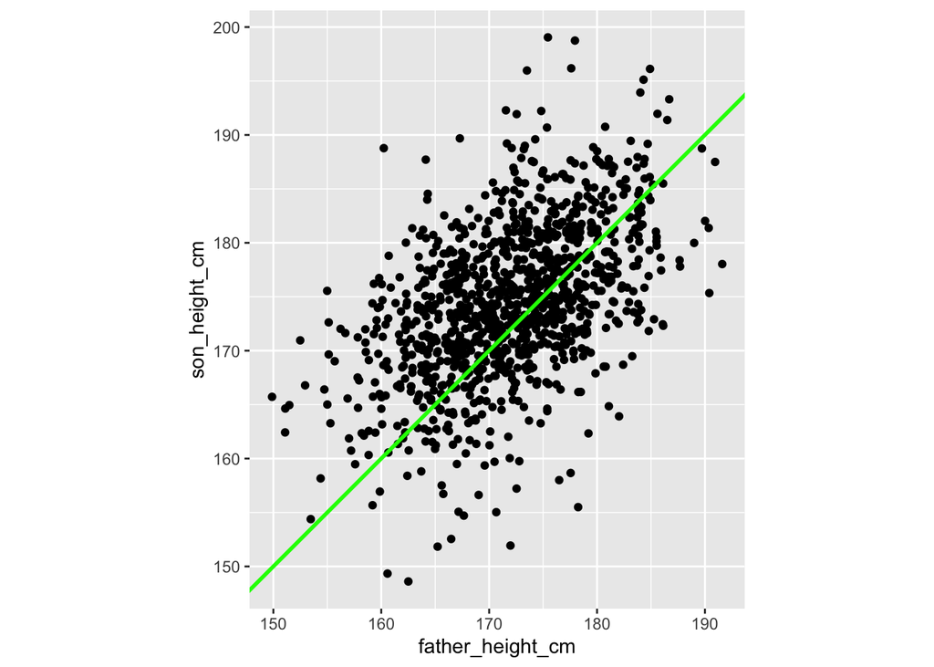

```r
plt_son_vs_father <- ggplot(
  father_son,
  aes(father_height_cm, son_height_cm)
) +
  geom_point() +
  geom_abline(color = "green", size = 1) +
  coord_fixed()

plt_son_vs_father
```

- Adding regression line:

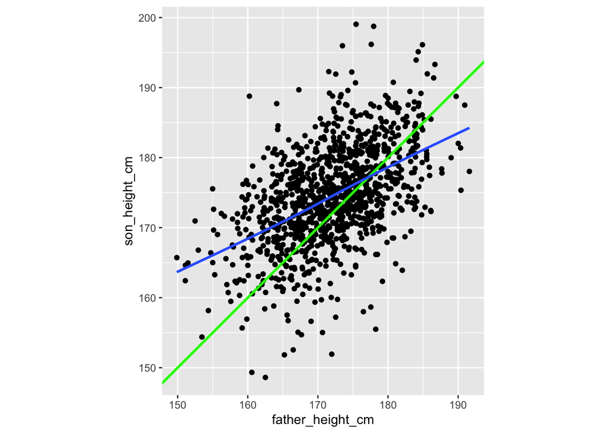

```r
plt_son_vs_father +
  geom_smooth(mehod = "lm", se = FALSE)
```

- Running a regression:

```r
mdl_son_vs_father <- lm(
  son_height_cm ~ father_height_cm,
  data = father_son
)
mdl_son_vs_father
```

```
##
## Call:
## lm(formula = son_height_cm ~ father_height_cm, data = father_son)
##
## Coefficients:
##      (Intercept)  father_height_cm
##          86.0720            0.5141
```

- Making predictions:

```r
really_tall_father <- tibble(
  father_height_cm = 190
)
predict(mdl_son_vs_father, really_tall_father)
```

```
##        1
## 183.7497
```

```r
really_tall_father <- tibble(
  father_height_cm = 150
)
predict(mdl_son_vs_father, really_tall_father)
```

```
##        1
## 163.1859
```

```r
churn <- read_fst(
  "churn.fst",
  columns = NULL,
  from = 1,
  to = NULL,
  as.data.table = FALSE,
  old_format = FALSE
)
```

# 6 Transforming Variables

- Sometimes, the relationship between the variables does not provide a straight line, so we need to transform the variables.
- We can transform both or just one of them.
- Data:

```r
library(rrcov)
data(fish)

perch <- fish %>%
  dplyr::filter(Species == 7) %>%
  dplyr::select(Weight, Length1)
names(perch) <- c("mass_g", "length_cm")
```

- Graph:

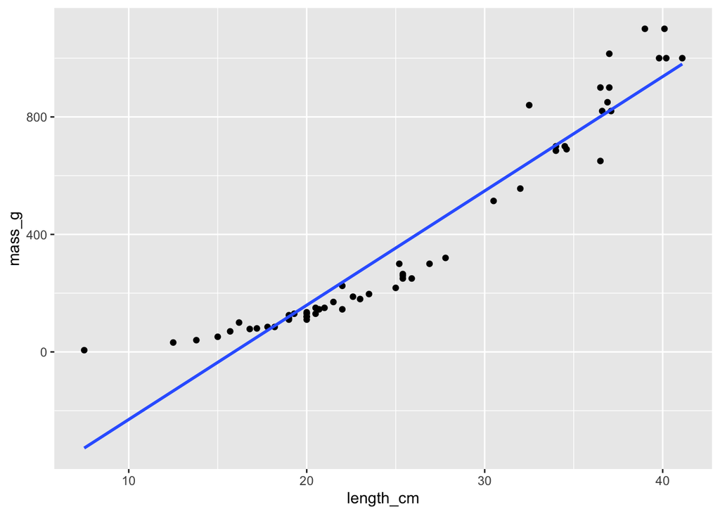

```r
ggplot(perch, aes(length_cm, mass_g)) +
  geom_point() +
  geom_smooth(method = "lm", se = FALSE)
```

- For this specific specie of fish, we can determine that it grows in three directions (because they are a bit fat) so we are going to transform the length to the power of 3.

[figure not shown]

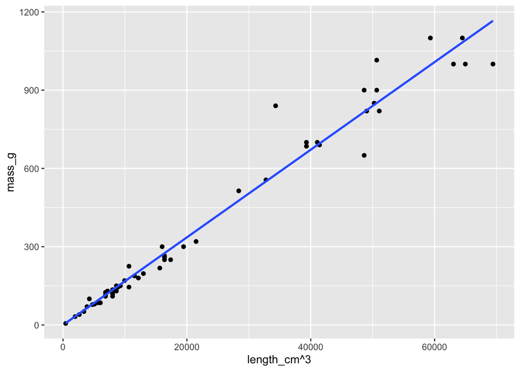

```r
ggplot(perch, aes(length_cm^3, mass_g)) +
  geom_point() +
  geom_smooth(method = "lm", se = FALSE)
```